# Assignment 8: Visualization - Making a bar race

*How to do it?*:

- Open the Rmarkdown file of this assignment (link) in Rstudio.
- Right under each **question**, insert a code chunk (you can use the hotkey `Ctrl + Alt + I` to add a code chunk) and code the solution for the question.
- `Knit` the rmarkdown file (hotkey: `Ctrl + Alt + K`) to export an html.
- Publish the html file to your Githiub Page.

*Submission*: Submit the link on Github of the assignment to Canvas

1. Install two packages `gganimate` and `gifski` then restart Rstudio. Using the `Adult Census Income` data, make an animation using `geom_point` and `transition_states`.

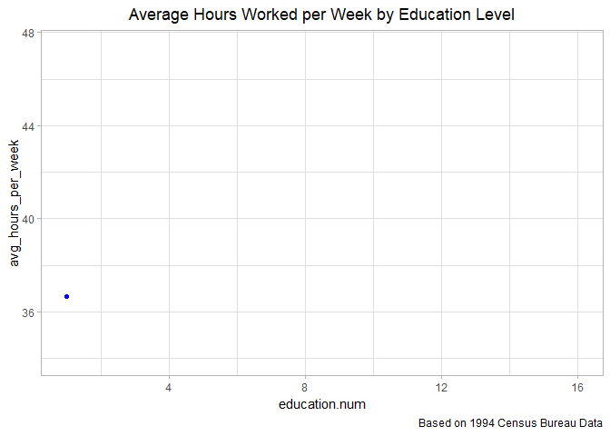

```r
# The line of code below was used to install the above packages
# install.packages(c('gganimate', 'gifski'))

# Loading packages
library(dplyr)
library(gganimate)
library(ggplot2)
library(tidyverse)
library(knitr)
library(lubridate)

# Reading in Adult Census Income data
df <- read_csv('adult_census.csv')

# Creating an animated plot
plot_1 <- df %>% group_by(education.num) %>% summarise (avg_hours_per_week = mean(hours.per.week)) %>% ggplot() + geom_point(mapping = aes(x=education.num, y=avg_hours_per_week), color = 'Blue') + transition_states(education.num) + ggtitle("Average Hours Worked per Week by Education Level") + labs(caption = "Based on 1994 Census Bureau Data") + theme_light() + theme(plot.title = element_text(hjust = 0.5)) + theme(plot.caption = element_text(hjust=1))

animate(plot_1)
```

2. Using the `Adult Census Income` data, make an animation using `geom_bar` and `transition_states`.

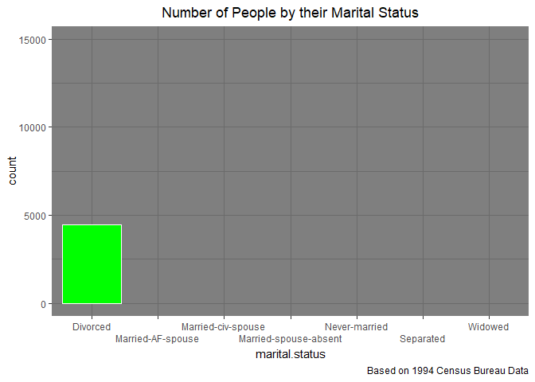

```r
plot_2 <- df %>% group_by(marital.status) %>% ggplot() + geom_bar(mapping = aes(x=marital.status), fill = 'Green', color = 'White') + transition_states(marital.status) + scale_x_discrete(guide = guide_axis(n.dodge = 2)) + ggtitle("Number of People by their Marital Status") + labs(caption = "Based on 1994 Census Bureau Data") + theme_dark() + theme(plot.title = element_text(hjust = 0.5)) + theme(plot.caption = element_text(hjust=1))

animate(plot_2)
```

3. Use the WHO’s dataset at [this link](https://covid19.who.int/WHO-COVID-19-global-data.csv). Make a top-10 bar race by months between countries on the number of deaths by Covid 19 in 2021.

```r
# Reading in WHO Covid-19 Data
covid_df <- read_csv('WHO-COVID-19-global-data.csv')
```

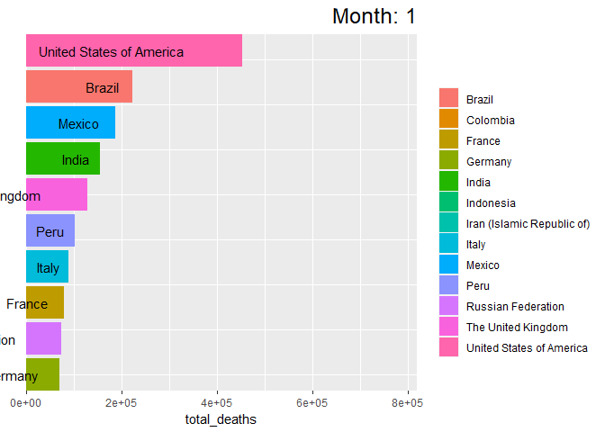

```r
# Creating month and year columns
covid_df$month <- month(covid_df$Date_reported)
covid_df$year <- year(covid_df$Date_reported)

# Creating Top-10 Bar Race
d1 <- covid_df %>% filter(year == 2021) %>%
  group_by(month, Country) %>%
  summarise(total_deaths = max(Cumulative_deaths))

#plot_3 <- d1 %>%
#  ggplot(aes(y=Country, x=total_deaths, fill = Country)) +
#  geom_col()+
#  transition_states(month)+
#  labs(title = 'Month: {closest_state}')

# animate(plot_3, nframes=400)

d2 <- d1 %>%
  group_by(month) %>%
  mutate(rank = rank(-total_deaths))

# plot_3 <- d2 %>%
  # ggplot(aes(y=factor(rank), x=total_deaths, group=Country, fill = Country)) +
  # geom_col()+
  # transition_states(month)+
  # labs(title = 'Month: {closest_state}')

# animate(plot_3, nframes=400)

d3 <- d2 %>% filter(rank <= 10)

plot_3 <- d3 %>% ggplot(aes(x=rank,
             y=total_deaths,
             group=Country,
             fill=Country,
             label=Country))+
     geom_col()+
    geom_text(aes(y = total_deaths,
                  label = Country),
              hjust = 1.4)+
    coord_flip(clip = "off",
               expand = FALSE)+
    scale_x_reverse()+
    labs(title='Month: {closest_state}', x='', fill='')+
    theme(plot.title =
          element_text(hjust=1,size=18),
          axis.ticks.y=element_blank(),
          axis.text.y=element_blank())+
    transition_states(month)+
    ease_aes("cubic-in-out")
animate(plot_3, nframes=200)
```

4. Make a bar race using a dataset of your own interest. You may use the dataset that we use in class (https://covidtracking.com/data/download/all-states-history.csv) but you should make a different bar race from ones in the slides.

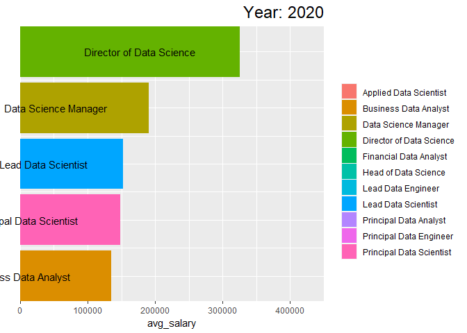

```r
options(scipen=999)

# Reading in salary data
salary_df <- read_csv('ds_salaries.csv')

# Creating a vector of job titles by which to filter
job_titles <- c('Applied Data Scientist', 'BI Data Analyst', 'Business Data Analyst', 'Data Science Manager', 'Director of Data Science', 'Financial Data Analyst', 'Head of Data Science', 'Lead Data Engineer', 'Lead Data Scientist', 'Principal Data Analyst', 'Principal Data Engineer', 'Principal Data Scientist')

# Creating bar race to compare the average salary for full time workers by year and job title
d4 <- salary_df %>% filter(employment_type == 'FT', job_title %in% job_titles) %>%
  group_by(work_year, job_title) %>%
  summarise(avg_salary = mean(salary_in_usd))

d5 <- d4 %>%
  group_by(work_year) %>%
  mutate(rank = rank(-avg_salary))

d6 <- d5 %>% filter(rank <= 5)

plot_4 <- d6 %>% ggplot(aes(x=rank,
             y=avg_salary,
             group=1,
             fill=job_title,
             label=job_title))+
     geom_col()+
    geom_text(aes(y = avg_salary,
                  label = job_title),
              hjust = 1.4)+
    coord_flip(clip = "off",
               expand = FALSE)+
    scale_x_reverse()+
    labs(title='Year: {closest_state}', x='', fill='')+
    theme(plot.title =
          element_text(hjust=1,size=18),
          axis.ticks.y=element_blank(),
          axis.text.y=element_blank())+
    transition_states(work_year)+
    ease_aes("cubic-in-out")
animate(plot_4, nframes = 100)
```